# Pickleball Paddle Analysis Using Plotnine(ggplot)

Ryan Bouchard, SIADS 521, Fall 2023

### Pickleball Paddle Data Exploration

I'm told that pickleball is all the rage these days, and not just with the kids. I live a couple blocks away from a senior center and you can hear them on the courts at the park from sunup to sundown. I'm trying to understand if this is going to be a collegiate sport in the future, with the scholarships that come with it, as I look into my daughter's eyes. Should I become the next King Richard), late father to Venus and Serena, and start training her with conviction? She might only be a year old, but I'm pretty sure she can hold a paddle. I can't walk onto these courts without understanding the intricate dynamics of the game. How am I going to judge and be judged in front of those seniors if I don't even know the difference between cheap, good, and over-priced gear? Luckily for me, it appears someone has done the grunt work of compiling a dataset of paddles on the market.

Data was sourced from [Gigasheet](https://www.gigasheet.com/sample-data/pickleball-paddle-stats), which is a company that offers cloud-based spreadsheet software. So they host some sample datasets on their website to showcase their product - I actually have no idea on the accuracy, completeness, or freshness of this paddle data, but it will give me a sense of what is going on in the exploding paddle market.

### Visualization Techniques: scatterplots, facet plots, facet-grid, jitter, themes

The dataset has information on price, but also things like weight, grip length, weight, and more. I have no idea which ones of those differentiate some paddles from others. In cases like this where I want to get a sense of where individual datapoints are, we're looking at scatterplots. And if we're looking at mostly numeric or continuous data and a few variables of categorical data, then we're going to want to find an efficient way to look at handfuls of scatterplots at a time. This is where faceting is really helpful, and when done well, is an efficient use of space because you can save pixels devoted to each plot having it's own axis labels (repeat information), and use more pixels for the actual plot areas. The alternative to scatterplots would be a series of barcharts, density plots, or boxplots. However, those plot only one variable at a time, so I can learn more about the relationship between two continuous variables through a scatterplot (i.e. identify if their are paddles that are inexpensive *and* lightweight).

Additionally, I want to consider situations in scatterplots where different data records with the same information (i.e. same x and y values in a plot) end up being plotted in a way that hides information when multiple records are plotted on top of each other. So I'm going to want to explore ways to expose when that occurs. Finally, I want the plots to look clean and presentation-worthy without having to do a lot of work, so built-in themes would be nice.

### Library Selection

ggplot2 is based on the *Grammer of Graphics* approach to data visualization and the concept of leveraging tidy data. It's a declarative approach that's relatively intuitive to get the hang of, has [great documentation](https://ggplot2.tidyverse.org/), and community support from people who have built courses, written books, and created example galleries. The only problem is that it's in R. For years it seemed like attempts to recreate this great library in python were shortlived - the open source repositories supporting ggplot and ggpy in python haven't been maintained and haven't accepted any contributions for years. But finally [plotnine](https://plotnine.readthedocs.io/) came along and seems to have the community backing support to make it worth investing time in.

There are already popular python visualization libraries like matplotlib and seaborn that can make 2-dimensional charts. However, many academics, researchers, and statisticians are exposed to R as their first open-source tool outside of statistical software. And ggplot2 is their equivalent to matplotlib in terms of it being one of the first libraries a new R user is exposed to. So if you're collaborating on projects or trying to figure out how to re-create or mimick a nice visual that someone has done with that background, then this might be a good library to get familiar with. It works well in Jupyter notebooks.

It can be installed in a few methods:

- pip in the command line: pip install plotnine
- [conda](https://anaconda.org/conda-forge/plotnine): conda install -c conda-forge plotnine
- GitHub: https://github.com/has2k1/plotnine

### Load Libraries, Packages, and Data

```python
# let's load libraries
import pandas as pd
import numpy as np
from plotnine import *

import warnings
warnings.filterwarnings('ignore')
```

Note: After going through the data I identified a few records that could be dropped or cleaned up to keep the emphasis on the visualization library and techniques.

```python
# let's load data
df = pd.read_excel('data/paddle_data.xlsx')

# clean data: remove some records with small sample size
df = df[df['Shape'] != 'Teardrop']
df = df[df['Face Material'] != 'Kevlar']
df = df[df['Face Material'] != 'Hybrid hitting surface']

# clean data: clean up 'Face material' categories
df = df.replace(to_replace = '.*Carbon Fiber.*', value = 'Carbon Fiber', regex = True)
df = df.replace(to_replace = '.*carbon fiber.*', value = 'Carbon Fiber', regex = True)
df = df.replace(to_replace = '.*Composite.*', value = 'Composite', regex = True)
```

```python
df.head()
```

|  | Record | Company | Paddle | Price | Face Material | Grip length | Core Material | Core thickness in mm | Grip thickness | Shape | ... | Weight | Swing weight | Twist Weight | YouTube Review | Link to Purchase | Discount Code | CODES | Notes | Discount | Paddle Tier |
| --- | --- | --- | --- | --- | --- | --- | --- | --- | --- | --- | --- | --- | --- | --- | --- | --- | --- | --- | --- | --- | --- |
| 0 | 1 | Adidas | Drive 2 | 69.99 | Fiberglass | 4.75 | Polymer Honeycomb | 14.0 | 4.125 | Standard | ... | 7.8-8.2oz | 105.0 | 7.11 | NaN | https://bit.ly/3HlC8lX | NaN | NaN | NaN | NaN | Cheap |
| 1 | 2 | Adidas | Match Light 2 | 69.99 | Fiberglass | 4.75 | Polymer Honeycomb | 14.0 | 4.125 | Standard | ... | 7.5-7.8oz | 96.0 | 6.68 | NaN | https://bit.ly/3HlC8lX | NaN | NaN | NaN | NaN | Cheap |
| 2 | 3 | Adidas | AdiPower Attk 2 | 199.99 | Carbon Fiber | 5.00 | Polymer Honeycomb | 14.0 | 4.125 | Elongated | ... | 7.8-8.2oz | 116.0 | 6.00 | NaN | https://bit.ly/3r5JGnX | NaN | NaN | NaN | NaN | High-end |
| 3 | 4 | Adidas | AdiPower CTRL | 199.99 | Carbon Fiber | 5.00 | Polymer Honeycomb | 14.0 | 4.125 | Standard | ... | 7.8-8.2oz | 111.0 | 6.82 | NaN | https://bit.ly/3sHB2fU | NaN | NaN | NaN | NaN | High-end |
| 4 | 5 | Adidas | Adipower Carbon Team | 159.99 | Carbon Fiber | 5.50 | Polymer Honeycomb | 16.0 | 4.500 | Elongated | ... | 7.8-8.2oz | 116.0 | 5.72 | NaN | https://bit.ly/45TIhQo | NaN | NaN | NaN | NaN | High-end |

5 rows × 21 columns

### Simple Scatterplot

So weight seems like it might be important for a paddle? I want to see how that correlates with price. I see that there's a data column for 'weight', but through a little research what I'm really interested in is [swing weight](https://pickleballscience.org/pickleball-paddle-swing-weight/) that is a better measure of how the weight feels in your hand.

Below is the base scatterplot we get with ggplot2. The basics of the library include:

- calling your data layer with ggplot()
- choosing your aestetic layer with aes(). Here we'll just specify the x and y axes using the names of those columns in our dataframe, but this is where we can specify more things like color, size, shape, and more.
- choosing the plotting layer. In ggplot the geom_point() generates a scatterplot, and we can additionally add aestetic specifics within the plotting layer to include color, size, shape, and more.

After viewing the plot, I think that there might be some points that are overlapping and that the chart might be hiding some information.

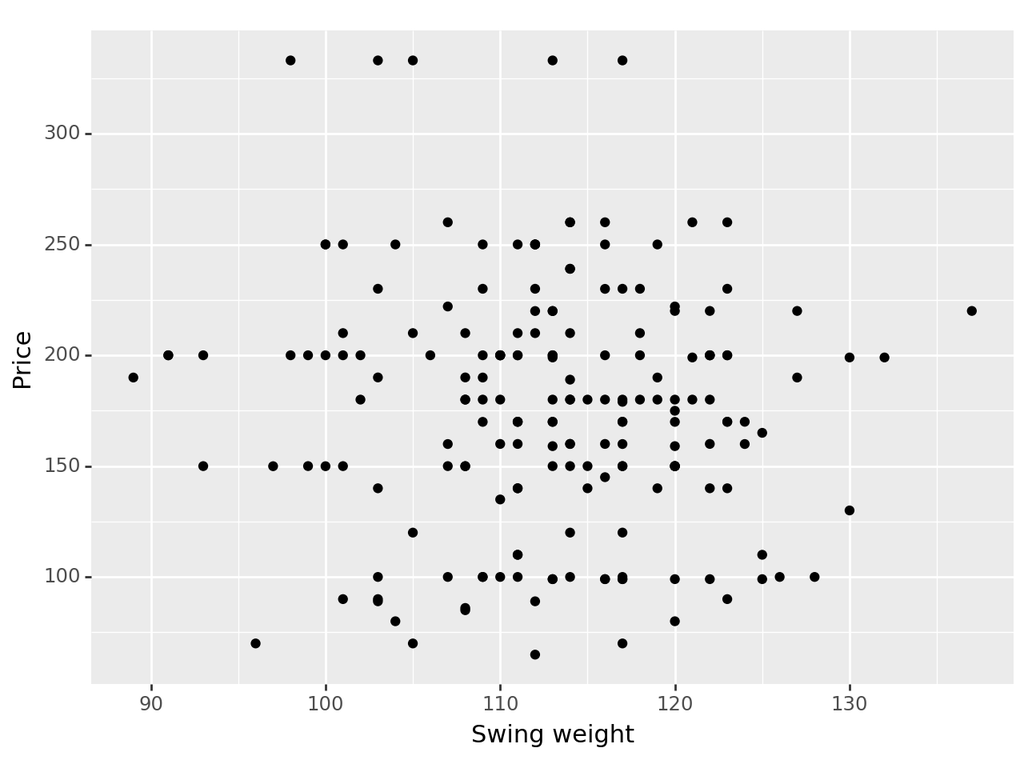

```
<Figure Size: (640 x 480)>
```

```python
(
    ggplot(df) # select data
    + aes(x = 'Swing weight', y = 'Price') # select variables for the aesthetic mapping
    + geom_point() # select plot type
)
```

Okay now I'm going to throw in some other functionality we get with plotnine(ggplot):

- We're able to change the color, transparency (alpha), and size for the points in our scatterplot. Making the points semi-transparent will allow us to get a better sense of points where there are multiple records (overlapping points).
- We're able to add a regression line to see if there's a relationship between the variables, and change the color of that too.
- We're able to add a title and axis labels
- We're able to add a theme to make it look better.

We can see from the regression line (and general distribution of points) that price doesn't appear to have any association with swing weight.

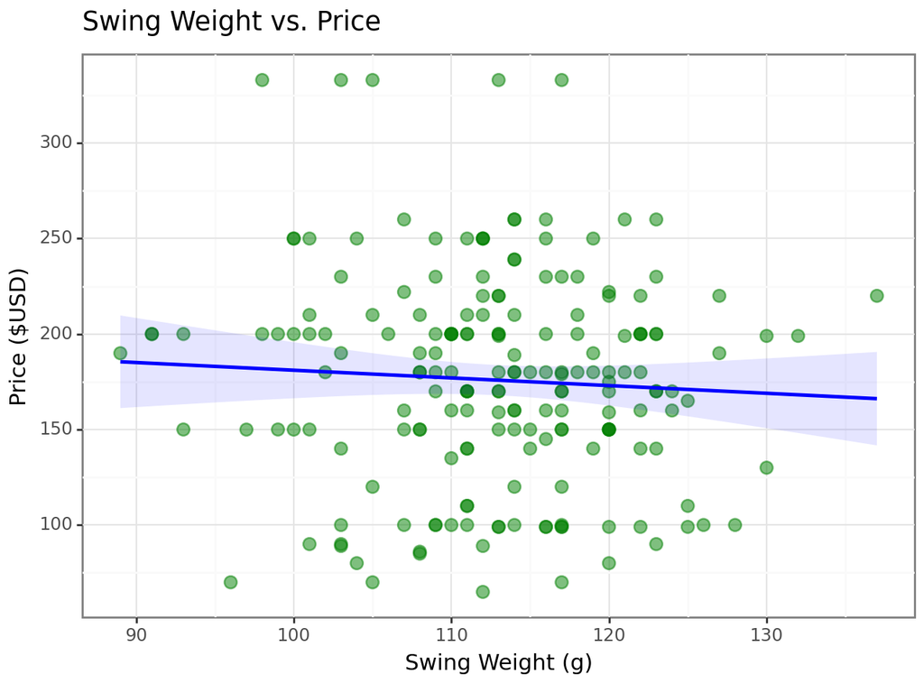

```
<Figure Size: (640 x 480)>
```

```python
(
    ggplot(df)
    + aes(x = 'Swing weight', y = 'Price')
    + geom_point(colour = 'green', alpha = 0.5, size = 3) # set the plot type layer and some aesthetics
    + geom_smooth(method = 'lm', colour = 'blue', fill = 'blue', alpha = 0.1) # add a regression line
    + ggtitle('Swing Weight vs. Price') # add title
    + labs(x = 'Swing Weight (g)', y = 'Price ($USD)') # add labels
    + theme_bw() # set theme
)
```

### The "Jitter"

The "jitter" technique is where the plotting library introduces a little noise in the plotting location to help give the reader a sense that there is a denser area of points. This is one way that the plotnine(ggplot) library is declarative, because the library user just needs to state the intent it decides how to do the rest. The user typically just needs to put "position = 'jitter'" in the plot layer aestetics, but in this case I wanted *more jitter* so I manually set how much noise to add.

As shown in the plot below, we can more easily identify a cluster of paddles on the market at the $150 and 120g swing weight point. In the plot above we adjusted the transparency of the points to try and identify overlapping records, but it is difficult to tell if it is two or more records at the same $150 / 120g location.

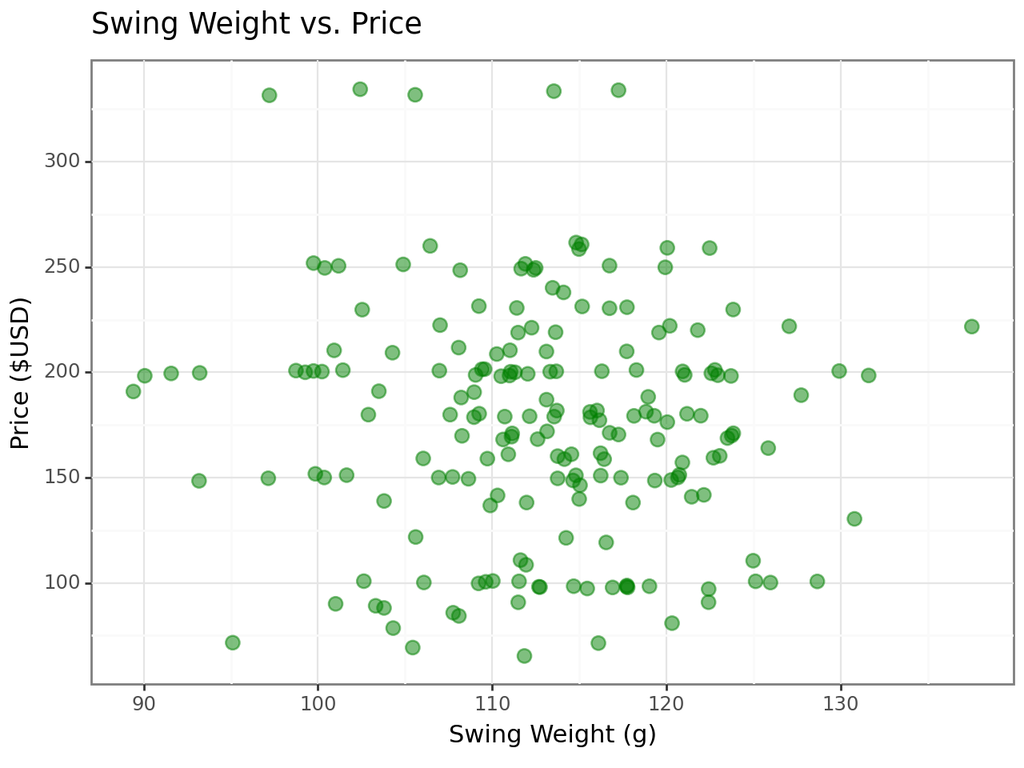

```
<Figure Size: (640 x 480)>
```

```python
(
    ggplot(df)
    + aes(x = 'Swing weight', y = 'Price')
    + geom_point(colour = 'green', alpha = 0.5, size = 3, position = position_jitter(width = 1, height = 2))
        # set the plot type and some aesthetics, plus the 'jitter' position adjustment
    + ggtitle('Swing Weight vs. Price')
    + labs(x = 'Swing Weight (g)', y = 'Price ($USD)')
    + theme_bw()
)
```

### Facet Plots

So now that we have two continuous variables on our scatterplot, we can layer in some categorical variables to further understand this paddle market. I'd like to know more about these paddles based on their shape and what price 'tier' they are in. 'Shape' is a categorical variable and I want to generate separate mini-plots for so I can better understand the paddle sub-markets for by shape. I put that variable in the additional facet_wrap() call and specify that I want these all along one row. 'Price Tier' is catagorical, and we add that as a color variable to our aestetic layer. This is again an example of this being a declarative tool, where we just put in the color variable but it chooses the colors and generates a legend.

In the plot below we see that most paddles are in the 'Elongated' and 'Standard' shape categories. Having facets along the row really allows me to stretch the price axis and see our points along that axis. Anything less expensive than about $75 is considered in the 'cheap' tier and anything above about $125 is in the 'high-end' tier of paddles.

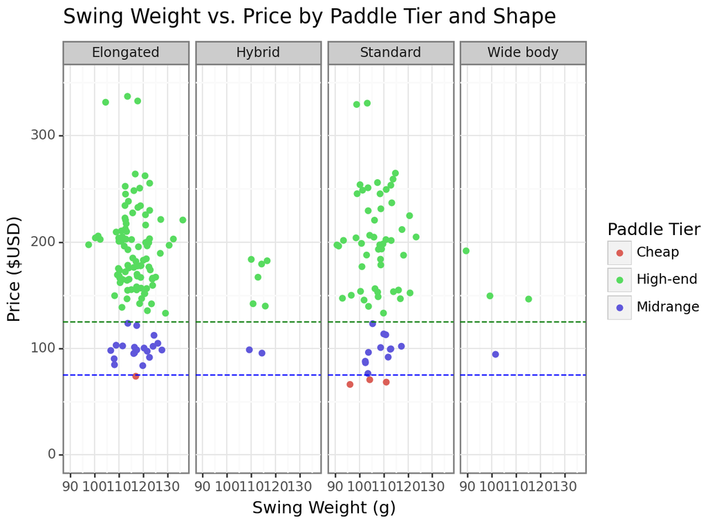

```
<Figure Size: (640 x 480)>
```

```python
(
    ggplot(df)
    + aes(x='Swing weight', y = 'Price', colour = 'Paddle Tier')
    + geom_point(position = position_jitter(width = 1, height = 5))
    + facet_wrap('Shape', nrow=1) # set facet and specify one row of plots
    + ylim(0, 350) # set y-axis limits so that we start price at $0
    + geom_hline(yintercept = 125, linetype = 'dashed', color = 'green') # add a horizontal line between tiers
    + geom_hline(yintercept = 75, linetype = 'dashed', color = 'blue')
    + ggtitle('Swing Weight vs. Price by Paddle Tier and Shape')
    + labs(x = 'Swing Weight (g)', y = 'Price ($USD)')
    + theme_bw()
)
```

```python
(
    ggplot(df)
    + aes(x='Swing weight', y = 'Price', colour = 'Face Material')
    + geom_point(shape = 5, size = 3)
    + ylim(0, 350)
    + facet_wrap('Shape') # set facet variable, but don't specify number of rows or columns
    + theme_bw()
)
```

[output not shown]

[output not shown]

[output cut: 98 more lines]

[output not shown]

### Facet Grid

Finally, we can also put our scatterplots across facets on columns and rows.

The component we add is:

facet_grid('row_variable ~ column variable')

In the plot below we can more clearly see that most of the cheap paddles have a fiberglass face with a light swing weight, but that there are also some up-market paddles with fiberglass faces too.

This also looks like a presentation-ready graphic, with a title and axis labels, that displays information consisting of *five variables* in a few organized lines of code.

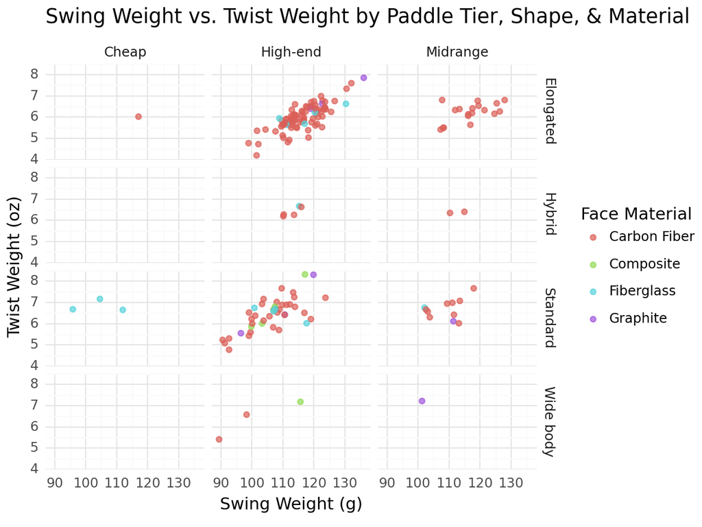

```
<Figure Size: (640 x 480)>
```

```python
(
    ggplot(df)
    + aes(x = 'Swing weight', y = 'Twist Weight', colour = 'Face Material')
    + geom_point(alpha=0.7, position = position_jitter(width = 1, height = 0.1))
    + facet_grid('Shape ~ Paddle Tier') # add a facet grid layer with two categorical variables
    + ggtitle('Swing Weight vs. Twist Weight by Paddle Tier, Shape, & Material')
    + labs(x = 'Swing Weight (g)', y = 'Twist Weight (oz)')
    + theme_minimal() # picked a different theme
)
```

Now that we've got the hang of this, we can start looking at some of the other variables and try out the FiveThirtyEight theme. Watch out Nate Silver!

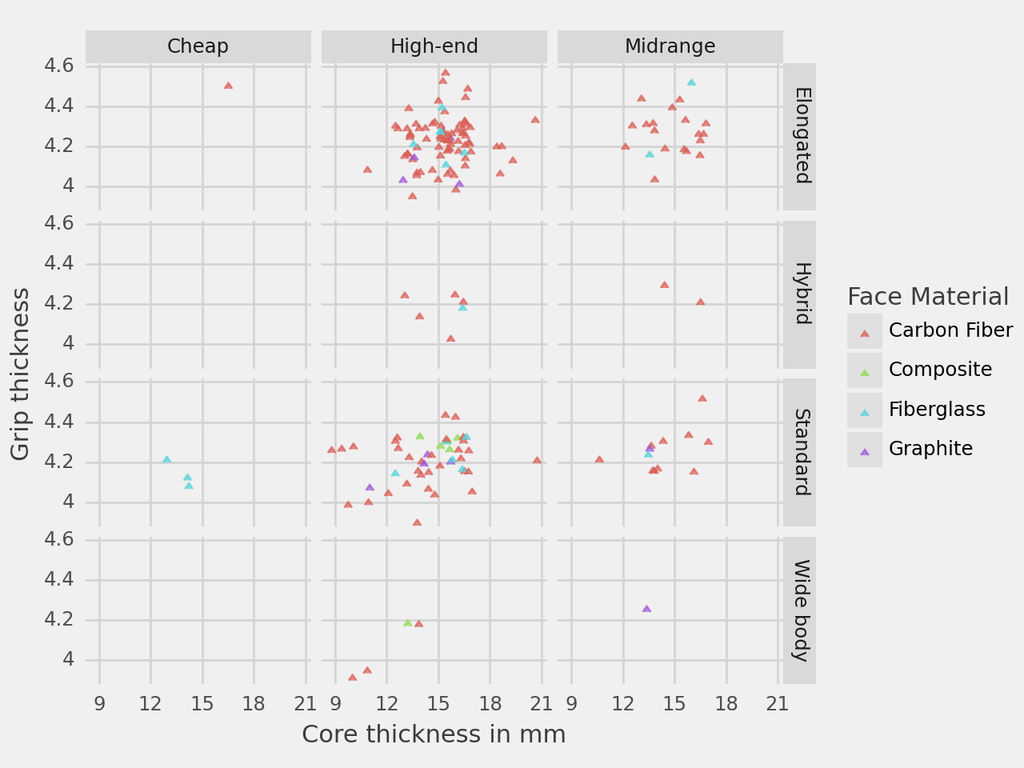

```
<Figure Size: (640 x 480)>
```

```python
(
    ggplot(df)
    + aes(x='Core thickness in mm', y = 'Grip thickness', colour = 'Face Material')
    + geom_point(shape = 6, alpha=0.7, position = position_jitter(width = 1, height = 0.1))
    + facet_grid('Shape ~ Paddle Tier')
    + theme_538()
)
```

And now we can check out price and RPM while making it look like it was generated with the help of the seaborn library.

It looks like there are some carbon fiber paddles that will let me put some wicked spin on the ball at ~$100 price point. However, we now see one drawback from using plotnine(ggplot) - this would be a good time to have some type of interactive plot that would allow me to identify the specific records on the scatterplot - is that the Adidas Drive 2 paddle that I need to purchase? I now need to filter my data to see exactly what those records are. This is where plotly express might be a better alternative.

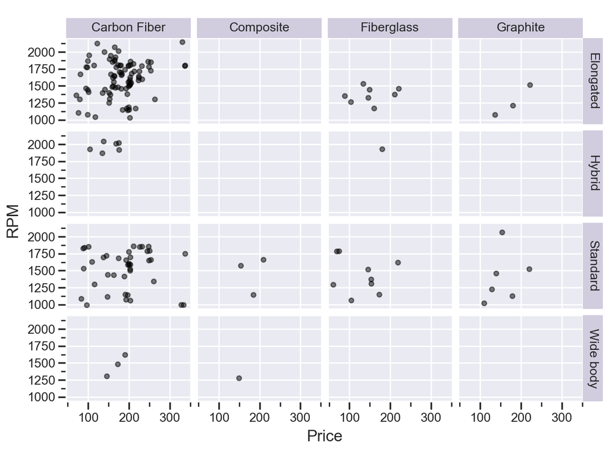

```
<Figure Size: (640 x 480)>
```

```python
(
    ggplot(df)
    + aes(x='Price', y = 'RPM')
    + geom_point(alpha=0.5, position = position_jitter(width = 5, height = 10))
    + facet_grid('Shape ~ Face Material')
    + theme_seaborn()
)
```

One other aspect is that we can make a ggplot object, and then add dimensions to that object. Here I create a 'MyPlot' object, and then apply a new theme.

*Apologies that this is going to generate a bunch of 'no font found' messages.*

[output not shown]

[output cut: 145 more lines]

[output not shown]

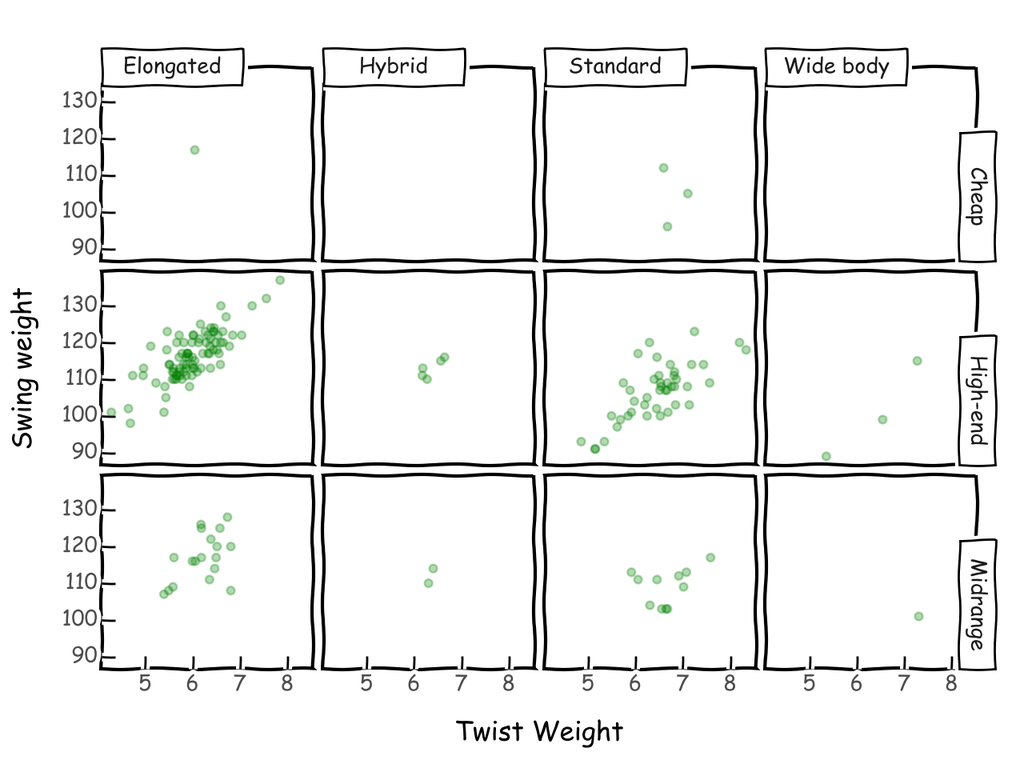

```
<Figure Size: (640 x 480)>
```

```python
MyPlot = (
    ggplot(df)
    + aes(x= 'Twist Weight', y = 'Swing weight')
    + geom_point(colour = 'green', alpha = 0.3)
    + facet_grid(facets= "Paddle Tier~Shape")
)

MyPlot + theme_xkcd()
```

That looks nice, and something I want to share with my friends. Let's save it as a png.

```python
# save MyPlot with new theme
MyPlot = MyPlot + theme_xkcd()

MyPlot.save('assets/plot_facet1.png', width = 10, height = 7, dpi = 300)
```

[output not shown]

[output cut: 156 more lines]

[output not shown]

## References

- Sample Pickleball Paddle Data from Gigasheet: https://www.gigasheet.com/sample-data/pickleball-paddle-stats
- Description of pickleball paddle swing weight: https://pickleballscience.org/pickleball-paddle-swing-weight/
- ggplot2 Documentation: https://ggplot2.tidyverse.org/
- Plotnine Library Documentation: https://plotnine.readthedocs.io/en/v0.12.4/
- Plotnine on PyPi: https://pypi.org/project/plotnine/
- Plotnine on Conda-Forge: https://anaconda.org/conda-forge/plotnine
- Plotnine GitHub Repository: https://github.com/has2k1/plotnine
- Plotly Express: https://plotly.com/python/line-and-scatter/